# Film Revenue Model

**Business understanding**  
[Project About](http://blog.jdnorthcott.com/2017/11/ready-set-go.html)

**Data understanding**  
[Inital Brain Dump of Python](http://blog.jdnorthcott.com/2017/11/python-scraper-brain-dump.html)  
[Initial Brain Dump of R](http://blog.jdnorthcott.com/2017/11/r-brain-dump.html)

**Data preparation**  
[Python Scraping Day One](http://blog.jdnorthcott.com/2017/11/implementing-python-scraper.html)  
[Python Scraping Day Two](http://blog.jdnorthcott.com/2017/12/implementing-python-scraper-day-two.html)  
[Python Scraping Day Three](http://blog.jdnorthcott.com/2017/12/implementing-python-scraper-day-three.html)  
Summary:

I ran into a bunch of issues while scraping the data. Those three blog posts show what I worked on each day and some of the problems that I ran into. I tried to update them live with my exact thoughts and how I worked through, or avoided, the problems that came up with Data Prepartion.

**Modeling**

I backwards fit my model. I removed the features in this order: avg_actor_film_votes, max_actor_film_stars, max_director_film_votes, avg_director_film_metascore, max_director_film_metascore, max_actor_film_metascore, day, avg_actor_film_metascore, avg_director_film_stars, month-avg_actor_age.

**Deployment**

I created a script that people can use to run the model. They need to have Python2.7 installed. Follow the directions in the README to use it. There is info on how to build the model from scratch as well in the README. I also have a blog post of potential improvements.

[Improvements](http://blog.jdnorthcott.com/2017/12/improvements-for-future-updates.html)

**Loading RMongo and linking to local database**

```r
require(RMongo)
mg1 <- mongoDbConnect('ds4100')
dbShowCollections(mg1)
```

```
character(0)
```

**Building the data.frame**  
Remove the following columns as they aren’t needed in the model  
X_id  
id  
FAILED  
mojo_id  
mojo_title  
stars  
metascore  
num_votes  
director  
actors  
release_date

Changes made in model 2.0 so far. Filtering out lengths less than 90 minutes.

```r
films <- dbGetQuery(mg1, 'films_agg', "{'FAILED': false, 'length': {'$gt': 90}}", 0, 15000)
films <- subset(films, select = -c(X_id, id, FAILED, mojo_id, mojo_title, stars, metascore, num_votes, director, actors, release_date))
```

**Map all Distinct MPAA values and create a “dictionary”**

```r
# Any non-sense values will be 0
# Go from NC-17 -> G being 1 - n
# Default value to return if string is something random
mpaa.int.default <- 0
mpaa.strings <- c(
    "NC-17",
    "R",
    "PG-13",
    "M/PG",
    "PG",
    "PASSED",
    "G"
)
mpaa.ints <- c(1:7)
# Setting the names of the ints to the corresponding ratings
names(mpaa.ints) <- mpaa.strings
# Test it out
mpaa.ints['R']
```

```
R
2
```

**Write a function to remap MPAA values to a number**

```r
# Takes a string rating and returns an int
mpaa.mapping<-function(rating) {
  if (rating %in% mpaa.strings) {
    return(mpaa.ints[rating])
  } else {
    return(mpaa.int.default)
  }
}
mpaa.mapping('R')   # 2
```

```
R
2
```

```r
mpaa.mapping('XXX') # 0
```

```
[1] 0
```

**Create new column in data.frame with mpaa ints**

```r
string_ratings <- films$mpaa
string_ints <- sapply(string_ratings, mpaa.mapping)
films$mpaa_num <- string_ints
films <- subset(films, select = -c(mpaa))
```

**Fix Directors Age (negative or 0 values)**

```r
avg_abv_zero_age <- mean(films$director_age[films$director_age > 0])
current_ages <- films$director_age
# Adjust the values to the average
adjusted_ages <- sapply(current_ages, function (a) if (a <= 0) {avg_abv_zero_age} else {a})
# Update the column
films$director_age <- adjusted_ages
```

**Display Pairs Panels (needs to be fixed)**

```r
require(psych)
pairs.panels(films)
```

**Dividing this into three models: low, medium and high**

**Low Budget 1 - 40 mil**

```r
low.budget.max = 40000000
low.budget.min = 1
length(films$revenue[films$budget <= low.budget.max & films$budget > low.budget.min])
```

```
[1] 4467
```

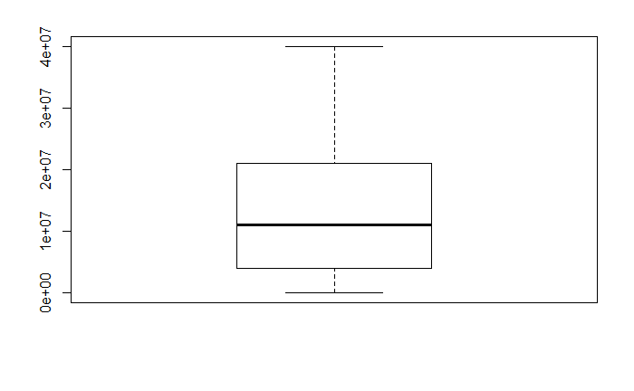

```r
boxplot(films$budget[films$budget <= low.budget.max & films$budget > low.budget.min])
```

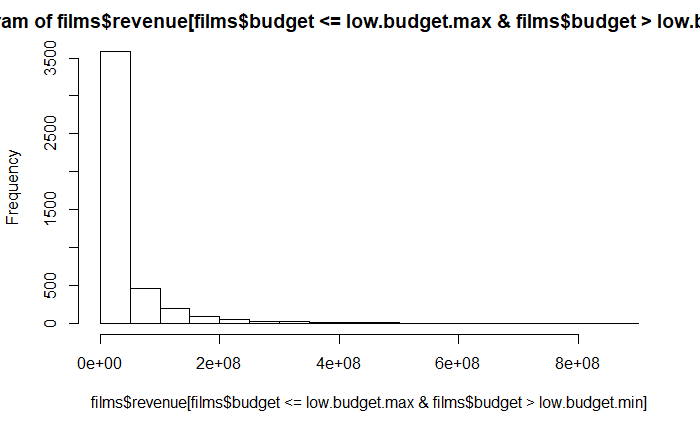

```r
hist(films$revenue[films$budget <= low.budget.max & films$budget > low.budget.min])
```

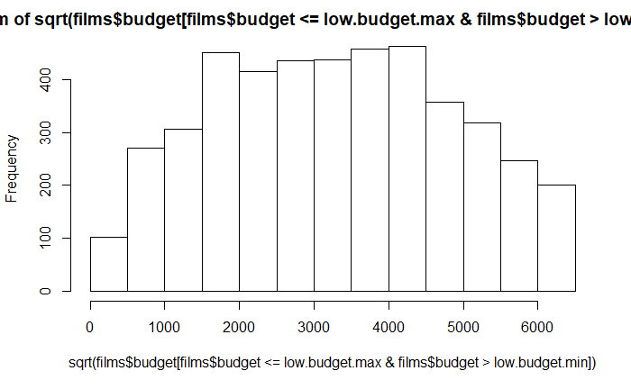

```r
hist(sqrt(films$budget[films$budget <= low.budget.max & films$budget > low.budget.min]))
```

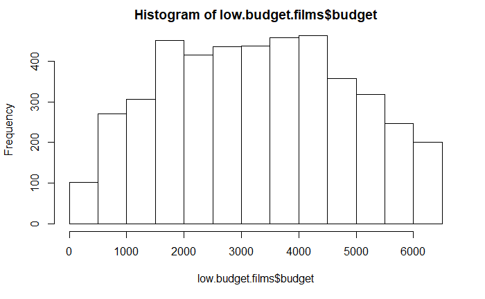

```r
low.budget.films <- subset(films, films$budget <= low.budget.max & films$budget > low.budget.min)
# Transforming by taking the sqrt of budget
low.budget.films$budget <- sqrt(low.budget.films$budget)
hist(low.budget.films$budget)
```

**Check Low Budget for Outliers in the following:** revenue  
length  
budget

```r
outliers.high<-function(f_data) {
  f_sd <- sd(f_data, na.rm = TRUE)
  f_avg <- mean(f_data, na.rm = TRUE)
  return(f_data[f_data >= (f_avg + f_sd * 2.5)])
}
outliers.low<-function(f_data) {
  f_sd <- sd(f_data, na.rm = TRUE)
  f_avg <- mean(f_data, na.rm = TRUE)
  return(f_data[f_data <= (f_avg - f_sd * 2.5)])
}
# Revenue
print("Revenue")
```

```
[1] "Revenue"
```

```r
print("High")
```

```
[1] "High"
```

```r
outliers.high(low.budget.films$revenue)
```

```
  [1] 356296601 205298907 231976425 358994850 318000141 393616788 234801895 244527583 333107271 216763646
 [11] 219076518 470653000 307166834 239606210 209638559 485930816 251171807 220443451 463406268 222724172
 [21] 309208309 326551094 269994119 205405498 216639112 455406554 312016858 210819611 194564672 350448145
 [31] 245700832 299965036 400176459 259368448 870325439 269958228 394955690 227514205 694146413 381109762
 [41] 235184110 216614388 285176741 222446882 266614059 317375031 276121886 348319861 288752301 305792201
 [51] 441286195 196200124 211952420 243240178 571006128 246942017 225933435 300473716 775398007 200512643
 [61] 354825435 281929795 476684675 256873813 369884651 231605150 389925971 226945087 320145693 287506194
 [71] 221303188 215862692 331950002 237113184 200687492 328203506 247275374 411006740 245066411 196114570
 [81] 356830601 467483912 235483004 368744044 538375067 316360478 216197492 312242626 213525736 201957688
 [91] 235860116 224920315 672806292 306889114 213954274 278304578 210308099 411348924 254139418 377910544
[101] 414211549 254134910 201634991 289317794 236412453 257938649 445670343 359126022 363164265 295212467
[111] 201750937 329398046 226830568 327311859 207945075 227853986 475106177 262520724 424208848 296999813
[121] 227799884 320270008 321731527 272742922 351583407 235455948 215394738 252276927 505702588 229163264
[131] 321306305 252909177 287553595 270665134
```

```r
print("Low")
```

```
[1] "Low"
```

```r
outliers.low(low.budget.films$revenue)
```

```
numeric(0)
```

```r
# Length
print("Length")
```

```
[1] "Length"
```

```r
print("High")
```

```
[1] "High"
```

```r
outliers.high(low.budget.films$length)
```

```
  [1] 161 153 153 162 162 161 153 191 159 153 157 153 158 188 175 181 155 189 165 163 174 159 154 153 238 205 170
 [28] 172 160 163 202 154 197 155 197 161 162 271 160 177 192 229 154 154 156 167 189 154 156 201 188 155 158 242
 [55] 153 158 154 157 172 158 180 155 171 195 168 154 165 155 226 156 175 180 161 163 165 207 162 216 152 165 270
 [82] 183 155 162 176 158 170 167 178 170 165 272 216 160 202 153 220 159 165 186 155 170 193 181 161 153 188 164
[109] 175 167 165 192 195 167 224 164
```

```r
print("Low")
```

```
[1] "Low"
```

```r
outliers.low(low.budget.films$length)
```

```
integer(0)
```

```r
# Budget
print("Budget")
```

```
[1] "Budget"
```

```r
print("High")
```

```
[1] "High"
```

```r
outliers.high(low.budget.films$budget)
```

```
numeric(0)
```

```r
print("Low")
```

```
[1] "Low"
```

```r
outliers.low(low.budget.films$budget)
```

```
numeric(0)
```

**Medium Budget 40mil - 120mil**

```r
medium.budget.max = 120000000
medium.budget.min = 40000000
length(films$revenue[films$budget <= medium.budget.max & films$budget > medium.budget.min])
```

```
[1] 976
```

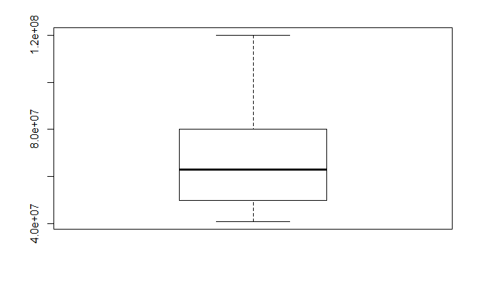

```r
boxplot(films$budget[films$budget <= medium.budget.max & films$budget > medium.budget.min])
```

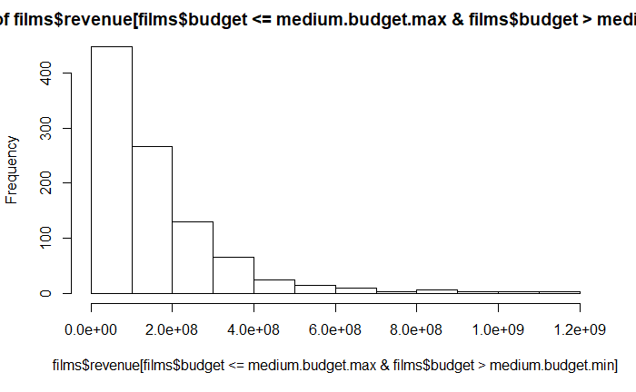

```r
hist(films$revenue[films$budget <= medium.budget.max & films$budget > medium.budget.min])
```

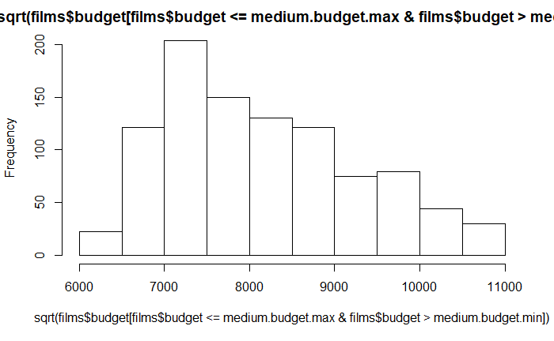

```r
hist(sqrt(films$budget[films$budget <= medium.budget.max & films$budget > medium.budget.min]))
```

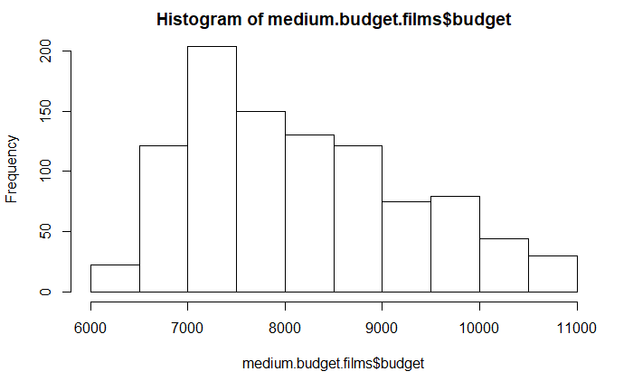

```r
medium.budget.films <- subset(films, films$budget <= medium.budget.max & films$budget > medium.budget.min)
# Transforming by taking the sqrt of budget
medium.budget.films$budget <- sqrt(medium.budget.films$budget)
hist(medium.budget.films$budget)
```

**Check Medium Budget for Outliers in the following:** revenue  
length  
budget

```r
outliers.high<-function(f_data) {
  f_sd <- sd(f_data, na.rm = TRUE)
  f_avg <- mean(f_data, na.rm = TRUE)
  return(f_data[f_data >= (f_avg + f_sd * 2.5)])
}
outliers.low<-function(f_data) {
  f_sd <- sd(f_data, na.rm = TRUE)
  f_avg <- mean(f_data, na.rm = TRUE)
  return(f_data[f_data <= (f_avg - f_sd * 2.5)])
}
# Revenue
print("Revenue")
```

```
[1] "Revenue"
```

```r
print("High")
```

```
[1] "High"
```

```r
outliers.high(medium.budget.films$revenue)
```

```
 [1]  563749323  589390539  926047111 1119929521  886686817  677945399  660940780  577425734  723192705
[10]  848754768  817400891 1027044677  871530324 1159398397 1029153882  878979634  586764305  630161890
[19]  609016565  783112979  694394724  829746820  574480841  970761885  609841637  633019734  709711008
[28]  618638999  698491347  940335536
```

```r
print("Low")
```

```
[1] "Low"
```

```r
outliers.low(medium.budget.films$revenue)
```

```
numeric(0)
```

```r
# Length
print("Length")
```

```
[1] "Length"
```

```r
print("High")
```

```
[1] "High"
```

```r
outliers.high(medium.budget.films$length)
```

```
 [1] 191 170 179 201 170 219 188 170 178 192 178 169 169 172 180 325 177 178 191 189 178 170 187 168 170 172
```

```r
print("Low")
```

```
[1] "Low"
```

```r
outliers.low(medium.budget.films$length)
```

```
integer(0)
```

```r
# Budget
print("Budget")
```

```
[1] "Budget"
```

```r
print("High")
```

```
[1] "High"
```

```r
outliers.high(medium.budget.films$budget)
```

```
numeric(0)
```

```r
print("Low")
```

```
[1] "Low"
```

```r
outliers.low(medium.budget.films$budget)
```

```
numeric(0)
```

**High Budget 120mil - max**

```r
high.budget.min = 120000000
length(films$revenue[films$budget > high.budget.min])
```

```
[1] 325
```

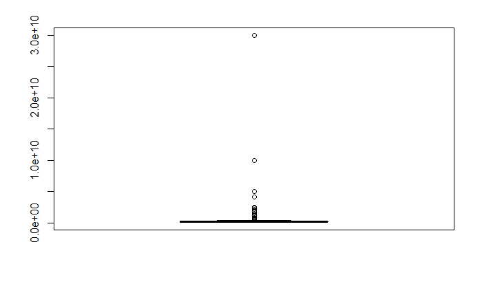

```r
boxplot(films$budget[films$budget > high.budget.min])
```

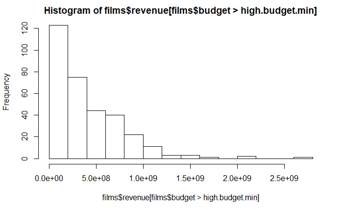

```r
hist(films$revenue[films$budget > high.budget.min])
```

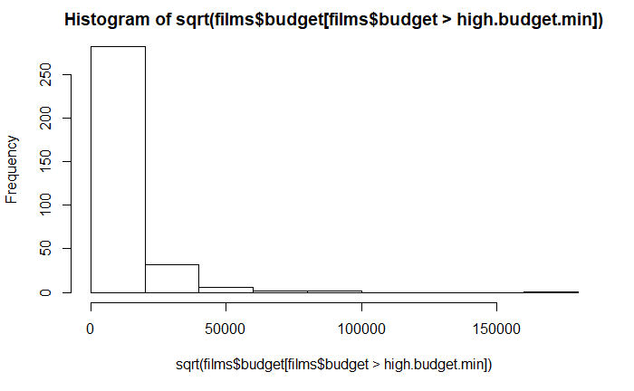

```r
hist(sqrt(films$budget[films$budget > high.budget.min]))
```

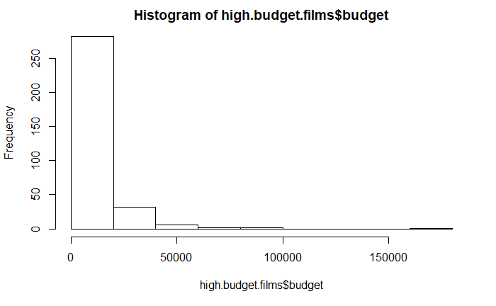

```r
high.budget.films <- subset(films, films$budget > high.budget.min)
# Transforming by taking the sqrt of budget
high.budget.films$budget <- sqrt(high.budget.films$budget)
hist(high.budget.films$budget)
```

**Check High Budget for Outliers in the following:** revenue  
length  
budget

```r
outliers.high<-function(f_data) {
  f_sd <- sd(f_data, na.rm = TRUE)
  f_avg <- mean(f_data, na.rm = TRUE)
  return(f_data[f_data >= (f_avg + f_sd * 2.5)])
}
outliers.low<-function(f_data) {
  f_sd <- sd(f_data, na.rm = TRUE)
  f_avg <- mean(f_data, na.rm = TRUE)
  return(f_data[f_data <= (f_avg - f_sd * 2.5)])
}
# Revenue
print("Revenue")
```

```
[1] "Revenue"
```

```r
print("High")
```

```
[1] "High"
```

```r
outliers.high(high.budget.films$revenue)
```

```
[1] 2787965087 1518812988 2068223624 1405403694 2187210904 1671713208 1516045911
```

```r
print("Low")
```

```
[1] "Low"
```

```r
outliers.low(high.budget.films$revenue)
```

```
numeric(0)
```

```r
# Length
print("Length")
```

```
[1] "Length"
```

```r
print("High")
```

```
[1] "High"
```

```r
outliers.high(high.budget.films$length)
```

```
[1] 197 193 194 210 255 213
```

```r
print("Low")
```

```
[1] "Low"
```

```r
outliers.low(high.budget.films$length)
```

```
integer(0)
```

```r
# Budget
print("Budget")
```

```
[1] "Budget"
```

```r
print("High")
```

```
[1] "High"
```

```r
outliers.high(high.budget.films$budget)
```

```
[1]  70710.68 100000.00  50000.00 173205.08 100000.00  64807.41
```

```r
print("Low")
```

```
[1] "Low"
```

```r
outliers.low(high.budget.films$budget)
```

```
numeric(0)
```

**Possible fields to be included in the model. Going to use backwards fitting to design the model**

revenue  
|  
v  
FILM SPECIFIC  
weekday  
day  
month  
budget  
length  
mpaa_num

ACTOR SPECIFIC  
avg_actor_age  
max_actor_film_revenue  
avg_actor_film_revenue  
max_actor_film_votes  
avg_actor_film_votes  
max_actor_film_stars  
avg_actor_film_stars  
max_actor_film_appearances  
avg_actor_film_appearances  
max_actor_film_metascore  
avg_actor_film_metascore

DIRECTOR SPECIFIC  
director_age  
director_number_of_films  
max_director_film_revenue  
avg_director_film_revenue  
max_director_film_votes  
avg_director_film_votes  
max_director_film_stars  
avg_director_film_stars  
max_director_film_metascore  
avg_director_film_metascore

```r
low.budget.revenue.lm <- lm(revenue ~ .-month-max_actor_film_stars-day-max_director_film_metascore-avg_actor_film_metascore-avg_actor_film_stars-avg_director_film_votes-max_director_film_stars-max_actor_film_votes-weekday-max_actor_film_metascore-director_number_of_films-avg_actor_film_votes-max_director_film_revenue-avg_director_film_metascore-avg_director_film_stars-max_actor_film_revenue, low.budget.films)
summary(low.budget.revenue.lm)
```

```
Call:
lm(formula = revenue ~ . - month - max_actor_film_stars - day -
    max_director_film_metascore - avg_actor_film_metascore -
    avg_actor_film_stars - avg_director_film_votes - max_director_film_stars -
    max_actor_film_votes - weekday - max_actor_film_metascore -
    director_number_of_films - avg_actor_film_votes - max_director_film_revenue -
    avg_director_film_metascore - avg_director_film_stars - max_actor_film_revenue,
    data = low.budget.films)

Residuals:
       Min         1Q     Median         3Q        Max
-146816216  -26765038   -9633920    8237665  799866594

Coefficients:
                             Estimate Std. Error t value Pr(>|t|)
(Intercept)                -5.871e+06  7.628e+06  -0.770  0.44151
avg_director_film_revenue   1.279e-01  2.192e-02   5.833 5.84e-09 ***
avg_actor_film_revenue      1.281e-01  2.460e-02   5.209 1.99e-07 ***
avg_actor_film_appearances -2.096e+06  3.696e+05  -5.670 1.52e-08 ***
max_actor_film_appearances  2.812e+05  1.055e+05   2.665  0.00772 **
budget                      1.182e+04  6.398e+02  18.466  < 2e-16 ***
director_age               -7.068e+05  9.223e+04  -7.663 2.22e-14 ***
max_director_film_votes     1.833e+01  6.473e+00   2.831  0.00466 **
length                      2.983e+05  5.398e+04   5.527 3.45e-08 ***
avg_actor_age              -3.274e+05  1.161e+05  -2.821  0.00481 **
mpaa_num                    3.759e+06  6.294e+05   5.971 2.54e-09 ***
---
Signif. codes:  0 *** 0.001 ** 0.01 * 0.05 . 0.1   1

Residual standard error: 57610000 on 4456 degrees of freedom
Multiple R-squared:  0.1883,    Adjusted R-squared:  0.1865
F-statistic: 103.4 on 10 and 4456 DF,  p-value: < 2.2e-16
```

```r
medium.budget.revenue.lm <- lm(revenue ~ .-max_director_film_metascore-avg_actor_age-max_actor_film_appearances-max_actor_film_stars-avg_director_film_metascore-avg_director_film_votes-avg_actor_film_appearances-max_actor_film_votes-max_director_film_revenue-avg_director_film_stars-max_director_film_stars-day-avg_actor_film_votes-max_director_film_votes-avg_actor_film_metascore-avg_actor_film_stars-month, medium.budget.films)
summary(medium.budget.revenue.lm)
```

```
Call:
lm(formula = revenue ~ . - max_director_film_metascore - avg_actor_age -
    max_actor_film_appearances - max_actor_film_stars - avg_director_film_metascore -
    avg_director_film_votes - avg_actor_film_appearances - max_actor_film_votes -
    max_director_film_revenue - avg_director_film_stars - max_director_film_stars -
    day - avg_actor_film_votes - max_director_film_votes - avg_actor_film_metascore -
    avg_actor_film_stars - month, data = medium.budget.films)

Residuals:
       Min         1Q     Median         3Q        Max
-445099898  -81181547  -20572505   50510932  823756242

Coefficients:
                            Estimate Std. Error t value Pr(>|t|)
(Intercept)               -1.089e+08  6.506e+07  -1.673 0.094577 .
max_actor_film_revenue    -8.356e-02  2.188e-02  -3.819 0.000143 ***
weekday                   -2.769e+07  6.299e+06  -4.395 1.23e-05 ***
avg_director_film_revenue  2.651e-01  5.049e-02   5.250 1.87e-07 ***
avg_actor_film_revenue     1.463e+00  1.405e-01  10.412  < 2e-16 ***
budget                     2.544e+04  3.823e+03   6.653 4.80e-11 ***
director_age              -2.481e+06  5.395e+05  -4.598 4.84e-06 ***
length                     5.628e+05  2.369e+05   2.376 0.017683 *
max_actor_film_metascore   9.217e+05  4.357e+05   2.116 0.034637 *
director_number_of_films   3.703e+06  1.153e+06   3.212 0.001361 **
mpaa_num                   1.497e+07  3.934e+06   3.805 0.000151 ***
---
Signif. codes:  0 *** 0.001 ** 0.01 * 0.05 . 0.1   1

Residual standard error: 133600000 on 965 degrees of freedom
Multiple R-squared:  0.3363,    Adjusted R-squared:  0.3295
F-statistic: 48.91 on 10 and 965 DF,  p-value: < 2.2e-16
```

```r
high.budget.revenue.lm <- lm(revenue ~ .-avg_actor_film_appearances-budget-avg_director_film_stars-max_actor_film_votes-max_actor_film_stars-avg_actor_film_stars-max_director_film_metascore-director_age-avg_actor_film_votes-weekday-max_actor_film_revenue-max_director_film_stars-day-avg_actor_film_metascore-max_actor_film_metascore-month, high.budget.films)
summary(high.budget.revenue.lm)
```

```
Call:
lm(formula = revenue ~ . - avg_actor_film_appearances - budget -
    avg_director_film_stars - max_actor_film_votes - max_actor_film_stars -
    avg_actor_film_stars - max_director_film_metascore - director_age -
    avg_actor_film_votes - weekday - max_actor_film_revenue -
    max_director_film_stars - day - avg_actor_film_metascore -
    max_actor_film_metascore - month, data = high.budget.films)

Residuals:
       Min         1Q     Median         3Q        Max
-691572507 -151612835  -17287726  105966949 1469061356

Coefficients:
                              Estimate Std. Error t value Pr(>|t|)
(Intercept)                 -1.429e+08  1.786e+08  -0.800 0.424213
avg_director_film_revenue   -1.344e+00  2.148e-01  -6.256 1.30e-09 ***
avg_actor_film_revenue       1.704e+00  2.627e-01   6.486 3.43e-10 ***
max_actor_film_appearances   2.864e+06  9.031e+05   3.172 0.001666 **
avg_director_film_votes      1.100e+03  2.882e+02   3.817 0.000163 ***
max_director_film_revenue    7.181e-01  1.173e-01   6.123 2.75e-09 ***
max_director_film_votes     -4.318e+02  1.278e+02  -3.378 0.000822 ***
length                       2.330e+06  7.789e+05   2.991 0.003002 **
director_number_of_films    -1.823e+07  5.574e+06  -3.270 0.001193 **
avg_actor_age               -6.369e+06  3.063e+06  -2.079 0.038439 *
avg_director_film_metascore  3.332e+06  7.939e+05   4.197 3.53e-05 ***
mpaa_num                     2.913e+07  1.305e+07   2.232 0.026347 *
---
Signif. codes:  0 *** 0.001 ** 0.01 * 0.05 . 0.1   1

Residual standard error: 276200000 on 313 degrees of freedom
Multiple R-squared:  0.5312,    Adjusted R-squared:  0.5147
F-statistic: 32.24 on 11 and 313 DF,  p-value: < 2.2e-16
```

**Only doing this for my best model** **Divide data into training and test**  
**Using a random 50/50 and 30/70 split**

```r
train.rows.50.50 <- sample(1:nrow(high.budget.films), round(nrow(high.budget.films) / 2), replace=F)
train.50.50 <- high.budget.films[train.rows.50.50,]
test.50.50 <- high.budget.films[-train.rows.50.50,]
train.rows.30.70 <- sample(1:nrow(high.budget.films), round(nrow(high.budget.films) / 3.33), replace=F)
train.30.70 <- high.budget.films[train.rows.30.70,]
test.30.70 <- high.budget.films[-train.rows.30.70,]
```

**Building the two test models**

```r
lm.50.50 <- lm(revenue ~ .-avg_actor_film_appearances-budget-avg_director_film_stars-max_actor_film_votes-max_actor_film_stars-avg_actor_film_stars-max_director_film_metascore-director_age-avg_actor_film_votes-weekday-max_actor_film_revenue-max_director_film_stars-day-avg_actor_film_metascore-max_actor_film_metascore-month, data=train.50.50)
lm.30.70 <- lm(revenue ~ .-avg_actor_film_appearances-budget-avg_director_film_stars-max_actor_film_votes-max_actor_film_stars-avg_actor_film_stars-max_director_film_metascore-director_age-avg_actor_film_votes-weekday-max_actor_film_revenue-max_director_film_stars-day-avg_actor_film_metascore-max_actor_film_metascore-month, data=train.30.70)
```

**Running the tests**

```r
results.50.50 <- sapply(1:nrow(test.50.50),function (r) predict(lm.50.50, test.50.50[r,]))
results.30.70 <- sapply(1:nrow(test.30.70),function (r) predict(lm.30.70, test.30.70[r,]))
```

**Checking % correct of both model tests**

```r
diffs.50.50 <- test.50.50$revenue - results.50.50
diffs.30.70 <- test.30.70$revenue - results.30.70
avg.diff.50.50 <- mean(abs(diffs.50.50))
avg.diff.30.70 <- mean(abs(diffs.30.70))
print(avg.diff.50.50)
```

```
[1] 200386135
```

```r
print(avg.diff.30.70)
```

```
[1] 207545068
```

**Coefficients used in Python**

```r
coefficients(revenue.lm)
```

```
               (Intercept)     max_actor_film_revenue                    weekday  avg_director_film_revenue
             -1.488033e+06               2.960269e-02              -1.791038e+06               3.787106e-01
    avg_actor_film_revenue    max_director_film_stars avg_actor_film_appearances max_actor_film_appearances
              2.314326e-01              -3.406501e+05              -2.317325e+06               1.223133e+06
   avg_director_film_votes                     budget  max_director_film_revenue               director_age
              1.566057e+02               1.245117e-02               1.391297e-01              -6.135633e+05
      max_actor_film_votes                     length   director_number_of_films       avg_actor_film_stars
              5.591624e+00               3.917203e+05              -1.376200e+06              -3.297309e+06
                  mpaa_num
              5.177258e+06
```